# Time Series Assignment 1

## EnerUSA: Total Primary Energy Consumption in USA

```r
serie=ts(read.table("EnerUSA.dat", header=F)/1000,start=1995,freq=12)
```

#### 11) The variance of the series increases with its level (mean), so we should take logarithms

Answer: $FALSE$

To assess the necessity of the logarithmic transformation, we need to plot the mean versus the variance and a boxplot. In this case, the first plot does not make clear whether variance increases with the mean, even though higher points are more common with higher values of the mean (but there are also similar variance values as with low levels). The second plot allows to have a better insight, and because the dispersion seems to be constant, we would not need a logarithmic transformation.

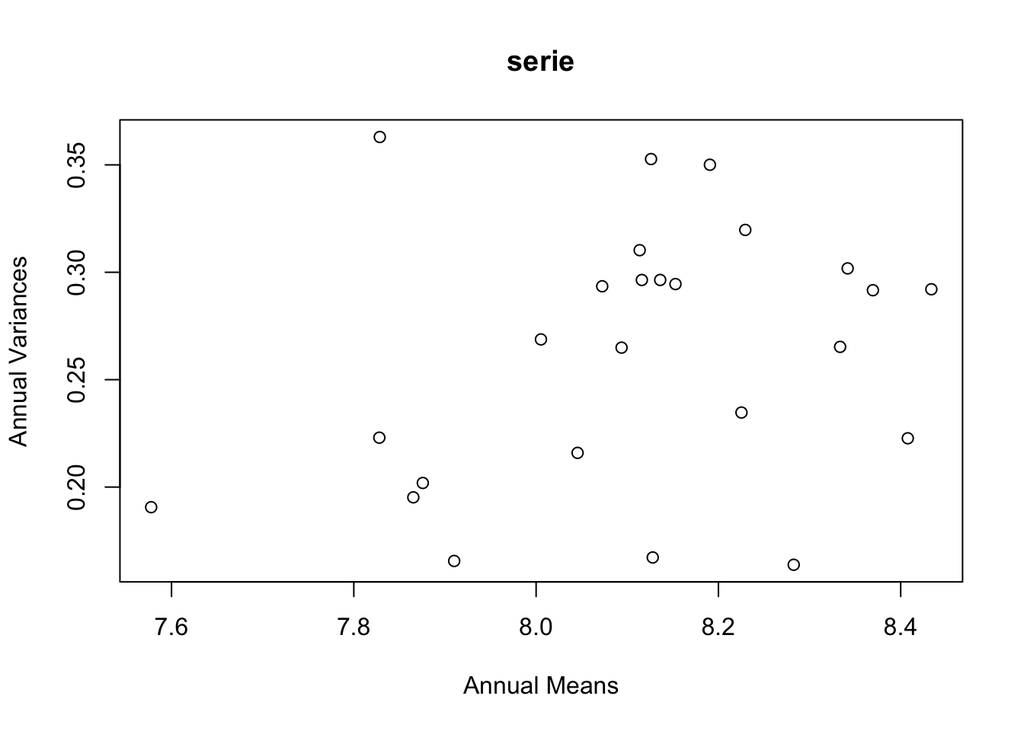

```r
m=apply(matrix(serie[1:(25*12)],nr=12),2,mean)
v=apply(matrix(serie[1:(25*12)],nr=12),2,var)
plot(m,v,xlab="Annual Means",ylab="Annual Variances",main="serie")
```

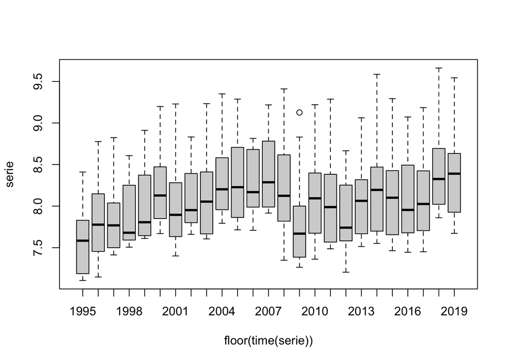

```r
boxplot(serie~floor(time(serie)))
```

#### 12) By looking at the ACF/PACF of the seasonally and regularly differenced series, an MA can be clearly identified for the seasonal part, and another MA for the regular part.

Answer: $FALSE$

For this question, we need to use the ACF and the PACF graphs to assess whether MA models can be identified for both the seasonal and the regular part.

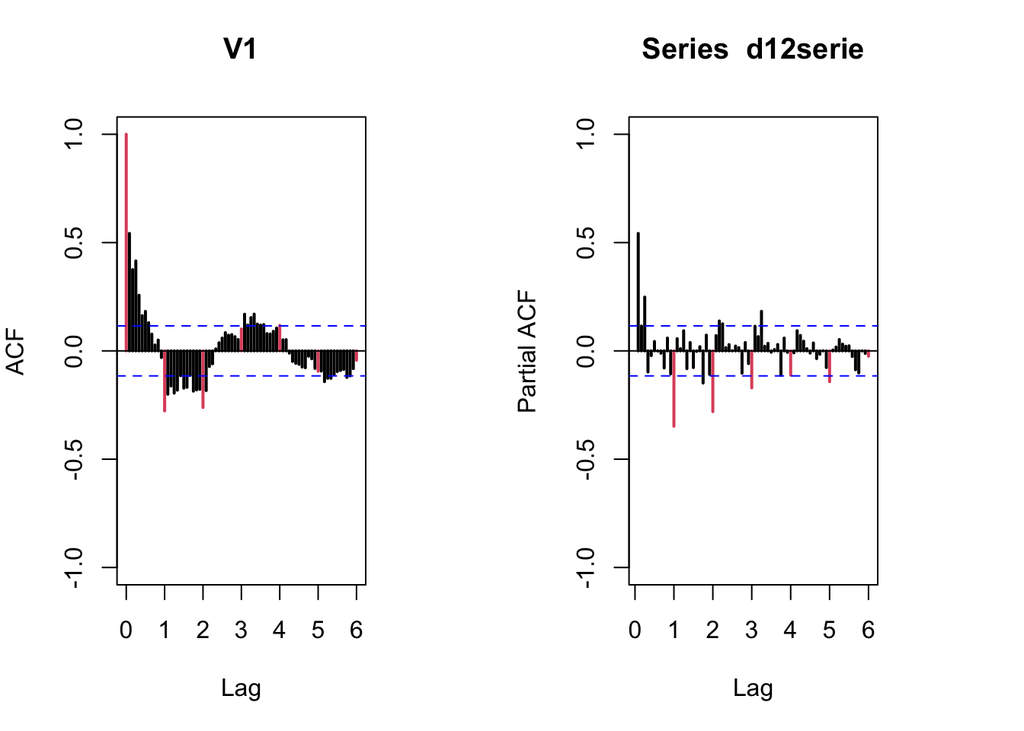

```r
d12serie=diff(serie,12)
par(mfrow=c(1,2), mar=c(5,4,4,5))
acf(d12serie,ylim=c(-1,1),col=c(2,rep(1,11)),lwd=2,lag.max=72)
pacf(d12serie,ylim=c(-1,1),col=c(rep(1,11),2),lwd=2,lag.max=72)
```

For the seasonal part, we can clearly identify and MA model because of the infinite decay of seasonal lags in the PACF, while the seasonal lags in the ACF seem to cut off at certain lags. In this part, we could use and MA(1) or MA(2). For the regular part, however, we would more likely identify an AR model, as there is a infinite decay of the regular lags in the ACF, while the regular lags in the PACF seem to cut off. For that part, we might identify an AR(2), for example. Consequently, we do not identify and MA for both the seasonal and the regular part.

#### 13) The $ARIMA(0,1, 2)(0,1,2)_{12}$ model yields better punctual predictions for the last 12 observations than the $ARIMA(3,0,0)(0,1,3)_{12}$ model with an intercept.

Answer: $FALSE$

To obtain the answer about the quality of predictions of both models, we have to compute forecasting measures such as the RMSE, MAE, RMSPE, MAPE and the mean CI length, which allow to compare how the models forecast.

Hence, we compute, again, the table we have computed in previous exercises. Likewise, we do not show the computation of the necessary elements for predictions, but just the results obtained by doing so.

```r
resul=data.frame(
  RMSE=c(fRMSE(obs,pr),fRMSE(obs1,pr1)),
  MAE=c(fMAE(obs,pr),fMAE(obs1,pr1)),
  RMSPE=c(fRMSPE(obs,pr),fRMSPE(obs1,pr1)),
  MAPE=c(fMAPE(obs,pr),fMAPE(obs1,pr1)),
  CI_Length=c(fCI(tu,tl),fCI(tu1,tl1)))
row.names(resul)=c("ARIMA(0,1, 2)(0,1,2)","ARIMA(3,0,0)(0,1,3)")
resul
```

```
##                           RMSE        MAE      RMSPE       MAPE CI_Length
## ARIMA(0,1, 2)(0,1,2) 0.1737406 0.15123593 0.02138503 0.01840705 0.8467449
## ARIMA(3,0,0)(0,1,3)  0.1264650 0.09868393 0.01537687 0.01188991 0.6336751
```

In this case, all measures favour the $ARIMA(3,0,0)(0,1,3)_{12}$ model when it comes to precision, accuracy, error and variability of punctual forecasts (measured by the mean length of the intervals). In this case, lower values indicate a better performance, so we can say that this model is better than the $ARIMA(0,1, 2)(0,1,2)_{12}$ model.

## APB: Mercantile Activity in the Port of Barcelona

```r
serie=window(ts(read.table("apb.dat")[,1]/1000,start=1997,freq=12),start=2000)
```

#### 14) The forecasts from the $ARIMA(0,1,1)(0,1,1)_{12}$ model for the last year are correct.

Answer: $TRUE$

In order to answer this question, we first need to estimate the model. We use a logarithmic transformation to estimate the model because of non-constant variance issues.

```r
lnserie=log(serie)
mod1=arima(lnserie,order=c(0,1,1),seasonal=list(order=c(0,1,1),period=12))
```

Once estimated, we proceed to do the forecasts for the model. We represent these punctual forecasts and their confidence interval in the following plot.

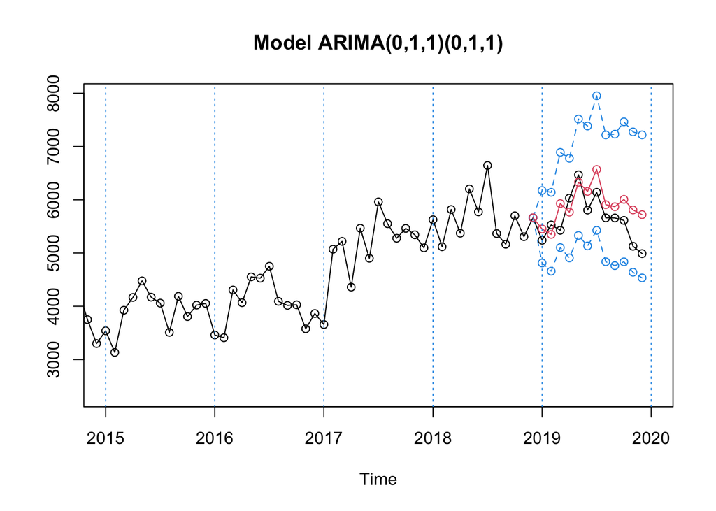

```r
ts.plot(serie,tl,tu,pr,lty=c(1,2,2,1),col=c(1,4,4,2),xlim=ultim[1]+c(-3,+2),type="o",main="Model ARIMA(0,1,1)(0,1,1)")
abline(v=(ultim[1]-3):(ultim[1]+2),lty=3,col=4)
```

As we can see, the forecasts are not exactly the observations, but this is logical. In order to give a better sense of the accuracy and precision for the forecast, we present the RMSPE and the MAPE.

```r
RMSPE=sqrt(sum(((obs-pr)/obs)^2)/12)
MAPE=sum(abs(obs-pr)/obs)/12
data.frame("RMSPE"= RMSPE,"MAPE"=MAPE)
```

```
##        RMSPE       MAPE
## 1 0.07620007 0.06603658
```

From the results we can clearly see that the model is quite precise and accurate, having very low values for the different errors. The values forecasted are near the real ones and inside the confidence bands.

#### 15) The Ljung-Box statistics for the previous model have p-values higher than 0.05 for all the lags, and that implies that the model is valid

Answer: $FALSE$

Finally, to answer the question we would need to use the validation function used in previous exercises. In order to use it, we do a seasonal and a regular difference to the logarithmic series, so that we work with a stationary series.

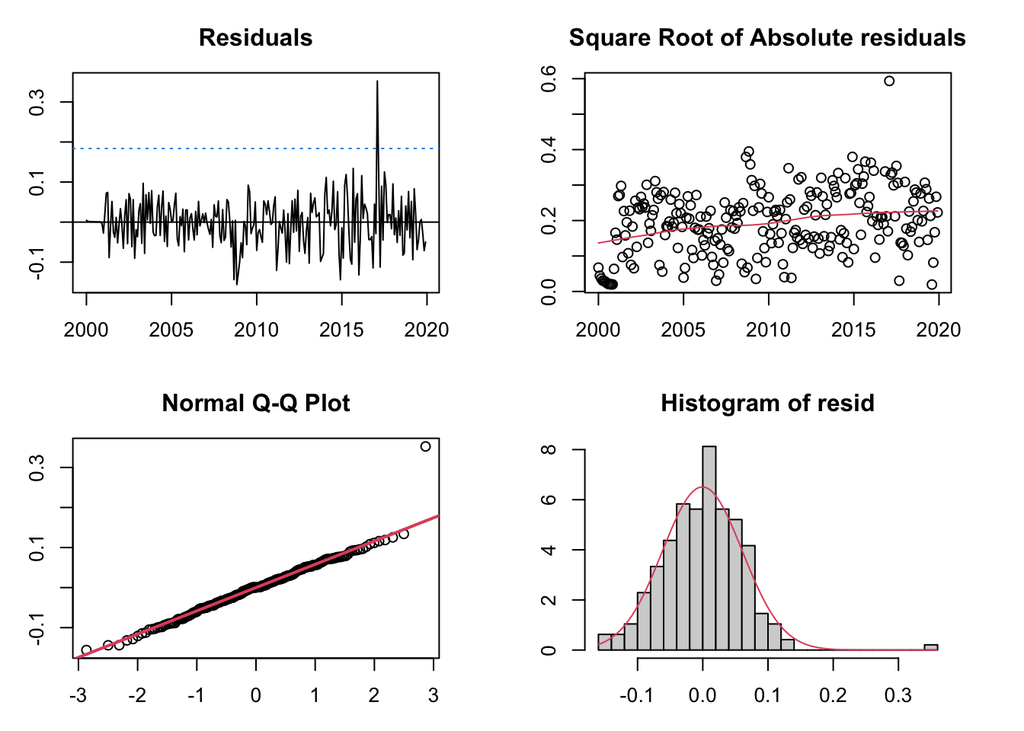

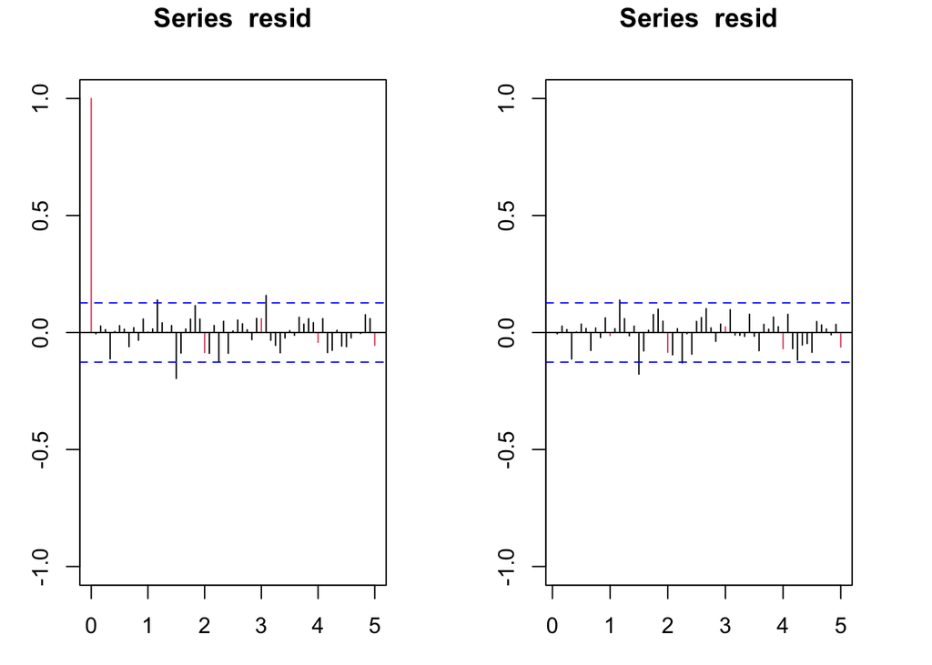

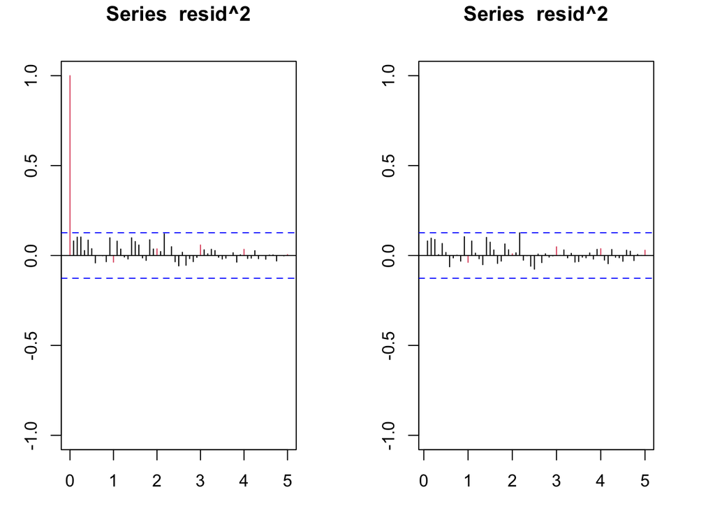

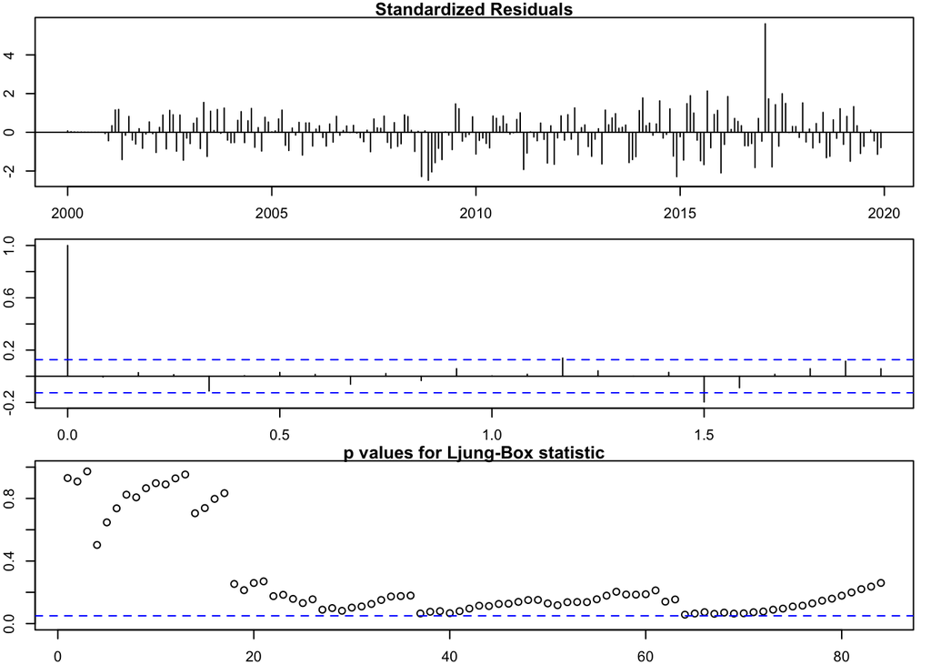

```
##
## --------------------------------------------------------------------
##
## Call:
## arima(x = lnserie, order = c(0, 1, 1), seasonal = list(order = c(0, 1, 1), period = 12))
##
## Coefficients:
##           ma1     sma1
##       -0.5299  -0.9278
## s.e.   0.0590   0.0762
##
## sigma^2 estimated as 0.00395:  log likelihood = 294.34,  aic = -582.68
##
## Modul of AR Characteristic polynomial Roots:
##
## Modul of MA Characteristic polynomial Roots:  1.006266 1.006266 1.006266 1.006266 1.006266 1.006266 1.006266 1.006266 1.006266 1.006266 1.006266 1.006266 1.886979
##
## Psi-weights (MA(inf))
##
## --------------------
##      psi 1      psi 2      psi 3      psi 4      psi 5      psi 6      psi 7
## -0.5299476  0.0000000  0.0000000  0.0000000  0.0000000  0.0000000  0.0000000
##      psi 8      psi 9     psi 10     psi 11     psi 12     psi 13     psi 14
##  0.0000000  0.0000000  0.0000000  0.0000000 -0.9277801  0.4916748  0.0000000
##     psi 15     psi 16     psi 17     psi 18     psi 19     psi 20
##  0.0000000  0.0000000  0.0000000  0.0000000  0.0000000  0.0000000
##
## Pi-weights (AR(inf))
##
## --------------------
##          pi 1          pi 2          pi 3          pi 4          pi 5
## -0.5299475747 -0.2808444319 -0.1488328255 -0.0788735949 -0.0417988703
##          pi 6          pi 7          pi 8          pi 9         pi 10
## -0.0221512100 -0.0117389800 -0.0062210440 -0.0032968272 -0.0017471456
##         pi 11         pi 12         pi 13         pi 14         pi 15
## -0.0009258956 -0.9282707985 -0.4919348583 -0.2606996850 -0.1381571658
##         pi 16         pi 17         pi 18         pi 19         pi 20
## -0.0732160549 -0.0388006707 -0.0205623214 -0.0108969523 -0.0057748135
##
##  Shapiro-Wilk normality test
##
## data:  resid(model)
## W = 0.96325, p-value = 7.761e-06
```

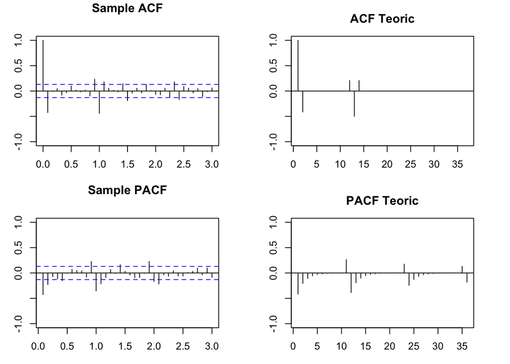

```r
d1d12lnserie=diff(diff(lnserie,12))
validation(mod1,d1d12lnserie)
```

From the results, one can clearly see that the Ljung-Box statistics are all above 0.05. However, time series models as the ones we work with do not need to be validated if other assumptions made on the models do not hold, such as normality or homoskedasticity. In this case, for example, normality is mostly holding (because of a single outlier that could be removed) and there is no sign of volatility, so we would validate this model. But, because of the Ljung-Box statistics above the significance level not being a sufficient condition to say that a model is valid, we would say this claim is false.